# Introduction

This vignette is intended to provide a first introduction to the R package `mitml` for generating and analyzing multiple imputations for multilevel missing data. A usual application of the package may consist of the following steps.

1. Imputation
2. Assessment of convergence
3. Completion of the data
4. Analysis
5. Pooling

The `mitml` package offers a set of tools to facilitate each of these steps. This vignette is intended as a step-by-step illustration of the basic features of `mitml`. Further information can be found in the other [vignettes](https://github.com/simongrund1/mitml/wiki) and the package [documentation](https://cran.r-project.org/package=mitml/mitml.pdf).

## Example data

For the purposes of this vignette, we employ a simple example that makes use of the `studentratings` data set, which is provided with `mitml`. To use it, the `mitml` package and the data set must be loaded as follows.

```r
library(mitml)
data(studentratings)
```

More information about the variables in the data set can be obtained from its `summary`.

```r
summary(studentratings)
```

```
#        ID       FedState     Sex              MathAchiev       MathDis
#  Min.   :1001   B :375   Length:750         Min.   :225.0   Min.   :0.2987
#  1st Qu.:1013   SH:375   Class :character   1st Qu.:440.7   1st Qu.:1.9594
#  Median :1513            Mode  :character   Median :492.7   Median :2.4350
#  Mean   :1513                               Mean   :495.4   Mean   :2.4717
#  3rd Qu.:2013                               3rd Qu.:553.2   3rd Qu.:3.0113
#  Max.   :2025                               Max.   :808.1   Max.   :4.7888
#                                             NA's   :132     NA's   :466
#       SES          ReadAchiev       ReadDis        CognAbility      SchClimate
#  Min.   :-9.00   Min.   :191.1   Min.   :0.7637   Min.   :28.89   Min.   :0.02449
#  1st Qu.:35.00   1st Qu.:427.4   1st Qu.:2.1249   1st Qu.:43.80   1st Qu.:1.15338
#  Median :46.00   Median :490.2   Median :2.5300   Median :48.69   Median :1.65636
#  Mean   :46.55   Mean   :489.9   Mean   :2.5899   Mean   :48.82   Mean   :1.73196
#  3rd Qu.:59.00   3rd Qu.:558.4   3rd Qu.:3.0663   3rd Qu.:53.94   3rd Qu.:2.24018
#  Max.   :93.00   Max.   :818.5   Max.   :4.8554   Max.   :71.29   Max.   :4.19316
#  NA's   :281                     NA's   :153                      NA's   :140
```

In addition, the correlations between variables (based on pairwise observations) may be useful for identifying possible sources of information that may be used during the treatment of missing data.

```
#             MathAchiev MathDis    SES ReadAchiev ReadDis CognAbility SchClimate
# MathAchiev       1.000  -0.106  0.260      0.497  -0.080       0.569     -0.206
# MathDis         -0.106   1.000 -0.206     -0.189   0.613      -0.203      0.412
# SES              0.260  -0.206  1.000      0.305  -0.153       0.138     -0.176
# ReadAchiev       0.497  -0.189  0.305      1.000  -0.297       0.413     -0.320
# ReadDis         -0.080   0.613 -0.153     -0.297   1.000      -0.162      0.417
# CognAbility      0.569  -0.203  0.138      0.413  -0.162       1.000     -0.266
# SchClimate      -0.206   0.412 -0.176     -0.320   0.417      -0.266      1.000
```

This illustrates that (a) most variables in the data set are affected by missing data, but also (b) that substantial relations exist between variables. For simplicity, we focus on only a subset of these variables.

## Model of interest

For the present example, we focus on the two variables `ReadDis` (disciplinary problems in reading class) and `ReadAchiev` (reading achievement).

Assume we are interested in the relation between these variables. Specifically, we may be interested in the following analysis model

$$\mathit{ReadAchiev}_{ij} = \gamma_{00} + \gamma_{10}
\mathit{ReadDis}_{ij} + u_{0j} + e_{ij}$$

On the basis of the syntax used in the R package `lme4`, this model may be written as follows.

```r
ReadAchiev ~ 1 + ReadDis + (1|ID)
```

In this model, the relation between `ReadDis` and `ReadAchiev` is represented by a single fixed effect of `ReadDis`, and a random intercept is included to account for the clustered structure of the data and the group-level variance in `ReadAchiev` that is not explained by `ReadDis`.

## Generating imputations

The `mitml` package includes wrapper functions for the R packages `pan` (`panImpute`) and `jomo` (`jomoImpute`). Here, we will use the first option. To generate imputations with `panImpute`, the user must specify (at least):

1. an imputation model
2. the number of iterations and imputations

The easiest way of specifying the imputation model is to use the `formula` argument of `panImpute`. Generally speaking, the imputation model should include all variables that are either (a) part of the model of interest, (b) related to the variables in the model, or (c) related to whether the variables in the model are missing.

In this simple example, we include only `ReadDis` and `ReadAchiev` as the main target variables and `SchClimate` as an auxiliary variable.

```r
fml <- ReadAchiev + ReadDis + SchClimate ~ 1 + (1|ID)
```

The imputation procedure is then run for 5,000 iterations (burn-in), after which 100 imputations are drawn every 100 iterations.

```r
imp <- panImpute(studentratings, formula = fml, n.burn = 5000, n.iter = 100, m = 100)
```

This step may take a few seconds. Once the process is completed, the imputations are saved in the `imp` object.

## Assessing convergence

In `mitml`, there are two options for assessing the convergence of the imputation procedure. First, the `summary` calculates the “potential scale reduction factor” ($\hat{R}$) for each parameter in the imputation model. If this value is noticeably larger than 1 for some parameters (say $>1.05$), a longer burn-in period may be required.

```r
summary(imp)
```

```
#
# Call:
#
# panImpute(data = studentratings, formula = fml, n.burn = 5000,
#     n.iter = 100, m = 100)
#
# Cluster variable:         ID
# Target variables:         ReadAchiev ReadDis SchClimate
# Fixed effect predictors:  (Intercept)
# Random effect predictors: (Intercept)
#
# Performed 5000 burn-in iterations, and generated 100 imputed data sets,
# each 100 iterations apart.
#
# Potential scale reduction (Rhat, imputation phase):
#
#          Min   25%  Mean Median   75%   Max
# Beta:  1.000 1.001 1.001  1.001 1.002 1.003
# Psi:   1.000 1.001 1.001  1.001 1.001 1.002
# Sigma: 1.000 1.000 1.000  1.000 1.000 1.001
#
# Largest potential scale reduction:
# Beta: [1,3], Psi: [2,1], Sigma: [2,1]
#
# Missing data per variable:
#     ID ReadAchiev ReadDis SchClimate FedState Sex MathAchiev MathDis SES  CognAbility
# MD% 0  0          20.4    18.7       0        0   17.6       62.1    37.5 0
```

Second, diagnostic plots can be requested with the `plot` function. These plots consist of a trace plot, an autocorrelation plot, and some additional information about the posterior distribution. Convergence can be assumed if the trace plot is stationary (i.e., does not “drift”), and the autocorrelation is within reasonable bounds for the chosen number of iterations between imputations.

For this example, we examine only the plot for the parameter `Beta[1,2]` (i.e., the intercept of `ReadDis`).

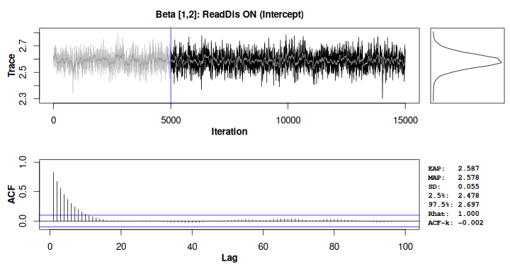

```r
plot(imp, trace = "all", print = "beta", pos = c(1,2))
```

Taken together, both $\hat{R}$ and the diagnostic plots indicate that the imputation model converged, setting the basis for the analysis of the imputed data sets.

## Completing the data

In order to work with and analyze the imputed data sets, the data sets must be completed with the imputations generated in the previous steps. To do so, `mitml` provides the function `mitmlComplete`.

```r
implist <- mitmlComplete(imp, "all")
```

This resulting object is a list that contains the 100 completed data sets.

## Analysis and pooling

In order to obtain estimates for the model of interest, the model must be fit separately to each of the completed data sets, and the results must be pooled into a final set of estimates and inferences. The `mitml` package offers the `with` function to fit various statistical models to a list of completed data sets.

In this example, we use the `lmer` function from the R package `lme4` to fit the model of interest.

```r
library(lme4)
fit <- with(implist, lmer(ReadAchiev ~ 1 + ReadDis + (1|ID)))
```

The resulting object is a list containing the 100 fitted models. To pool the results of these models into a set of final estimates and inferences, `mitml` offers the `testEstimates` function.

```r
testEstimates(fit, extra.pars = TRUE)
```

```
#
# Call:
#
# testEstimates(model = fit, extra.pars = TRUE)
#
# Final parameter estimates and inferences obtained from 100 imputed data sets.
#
#              Estimate Std.Error   t.value        df   P(>|t|)       RIV       FMI
# (Intercept)   582.186    14.501    40.147  4335.314     0.000     0.178     0.152
# ReadDis       -35.689     5.231    -6.822  3239.411     0.000     0.212     0.175
#
#                         Estimate
# Intercept~~Intercept|ID  902.868
# Residual~~Residual      6996.303
# ICC|ID                     0.114
#
# Unadjusted hypothesis test as appropriate in larger samples.
```

The estimates can be interpreted in a manner similar to the estimates from the corresponding complete-data procedure. In addition, the output includes diagnostic quantities such as the fraction of missing information (FMI), which can be helpful for interpreting the results and understanding problems with the imputation procedure.

###### References

Grund, S., Lüdtke, O., & Robitzsch, A. (2016). Multiple imputation of multilevel missing data: An introduction to the R package pan. *SAGE Open*, *6*(4), 1–17. doi: 10.1177/2158244016668220 ([Link](https://doi.org/10.1177/2158244016668220))

Grund, S., Lüdtke, O., & Robitzsch, A. (2018). Multiple imputation of missing data for multilevel models: Simulations and recommendations. *Organizational Research Methods*, *21*(1), 111–149. doi: 10.1177/1094428117703686 ([Link](https://doi.org/10.1177/1094428117703686))

```
# Author: Simon Grund (simon.grund@uni-hamburg.de)
# Date:   2023-03-08
```